[figure not shown]

# 4. Teorija grafov

### Andrej Košir, Lucami, FE

#### Kontakt: prof. dr. Andrej Košir, andrej.kosir@lucami.fe.uni-lj.si, skype=akosir_sid

1

[figure not shown]

4. Teorija grafov

Cilji

## ■ Cilji

- Spoznati podatkovno strukturo graf, ki je osnovna predstavitev omrežja in hkrati osnova za več optimizacijskih algoritmov
- Spoznati predstavitev grafov v računalniku
- Spoznati osnovna sprehoda po grafu
- Spoznati pomembne pojme, relevantne za optimizacijo

2

[figure not shown]

4. Teorija grafov

Poglavja

## ■ Poglavja

### 4.1 Definicija, predstavitev in osnovne lastnosti

■ Definicija grafa in podatkovna struktura graf $\large{*}$

■ Vrste grafov $\large{*}$

■ Predstavitev grafa: matrika sosednosti in matrika mreže $\large{*}$

■ Predstavitev grafa: seznam sosedov $\large{*}$

■ Matrika razdalj in Laplaceova matrika

■ Stopnja vozlišča in regularnost

■ Vložitev in označevanje grafa $\large{*}$

3

[figure not shown]

4. Teorija grafov

Poglavja

### 4.2. Izbrani problemi in algoritmi na grafih

■ Pregled grafa $\large{*}$

■ Podgraf, sprehod, pot, cikel $\large{*}$

■ Hamiltonova pot in cikel $\large{*}$

■ Klika in neodvisna podmnožica

■ Najmanjše vpeto drevo $\large{*}$

■ Povezanost grafa $\large{*}$

■ Ravninski grafi $\large{*}$

■ Barvanje grafa

■ Problem najkrajše (najcenejše) poti $\large{*}$

■ Problem maksimalnega pretoka $\large{*}$

■ Problem trgovskega potnika

■ Risanje grafov

4

[figure not shown]

4. Teorija grafov

Uvod, zgodovina

## ■ Uvod, zgodovina

- 1736: Euler in mostovi v Königsbergu:
  - Ali je mogoč sprehod, ki vsak most obišče natanko enkrat? Ne.
  - Eulerjev graf
  - Eulerjeva karakteristika

[figure not shown]

- 100 let kasneje: diferencialni račun, teorija grup, ...
- Danes
  - Diskretna matematika
  - Optimizacija
  - Algoritmi
  - Kemija
  - Teorija grup

[figure not shown]

5

[figure not shown]

4. Teorija grafov

Uvod, zgodovina

## Uporaba grafov: vizualizacija odločitvenih dreves

[figure not shown]

6

[figure not shown]

4. Teorija grafov

4.1 Definicija, predstavitev in osnovne lastnosti

## 4.1 Definicija, predstavitev in osnovne lastnosti

■ Definicija grafa in podatkovna struktura graf

■ Pomembni primeri grafov

■ Predstavitev grafa - matrika sosednosti in matrika mreže

■ Predstavitev grafa - seznam sosesdnosti

■ Matrika razdalj in Laplaceova matrika

■ Stopnja vozlišča in regularnost

■ Vložitev in označevanje grafa

7

[figure not shown]

4. Teorija grafov

4.1 Definicija, predstavitev in osnovne lastnosti

## ■ Definicija grafa in podatkovna struktura graf

- Podatkovna struktura
- Teoretični opis $G=(V,E)$  
  $V=\{1, \ldots, |V|\}$  
  $E=\{(u,v): \mbox{nekatere}\; u,v\in E\}$  
  Izmenoma uporabljamo oznako  
  za povezavo $(u,v)=(uv)=uv$

[figure not shown]

#### Vrste grafov

- Neusmerjeni graf (graf) in usmerjeni graf (digraf)
- Enostaven graf (nima zank in vzporednih povezav)
- redek graf, gost graf

8

[figure not shown]

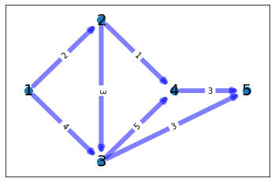

```python
import networkx as nx
import matplotlib.pyplot as plt
import graphviz as grv


# Create network graph with distances
G = nx.DiGraph()
E = [('1','2',2), ('1','3',4), ('2','3',3), ('2','4',1), ('3','4',5), ('3','5',3), ('4','5',3)]
G.add_weighted_edges_from(E)

# Draw it
plt.figure(1)
#pos = nx.graphviz_layout(G)
#pos = nx.spring_layout(G)
#pos = nx.graphviz_layout(G)
#pos = nx.pydot_layout(G)
pos = {'1': [1,2], '2': [2,3], '3': [2,1], '4':[3,2], '5':[4,2]}
nx.draw_networkx_nodes(G,pos, node_size=100)
nx.draw_networkx_edges(G,pos, width=6,alpha=0.5,edge_color='b') #,style='dashed')
nx.draw_networkx_labels(G,pos,font_size=20)

edge_labels=dict([((u,v,),d['weight']) for u,v,d in G.edges(data=True)])
nx.draw_networkx_edge_labels(G,pos,edge_labels=edge_labels)

plt.show()
```

4. Teorija grafov

4.1 Definicija, predstavitev in osnovne lastnosti

## ■ Pomembni primeri grafov

- Označimo graf: $G=(V(G), E(G))$
  - Prazen graf: $E=\{\}$
  - Poln graf: $K_n = (\{1,…,n\}, \{(u,v): u,v∈V\})$
  - Bipartitni graf: $K_{(n_1,n_2)}$
  - K-partitni graf: $K_{(n_1,n_2,… n_K)}$
  - Redek graf: blizu praznemu
  - Gost graf: blizu polnemu
  - Drevo, binarno drevo

9

[figure not shown]

4. Teorija grafov

4.1 Definicija, predstavitev in osnovne lastnosti

## ■ Predstavitev grafa - matrika sosednosti in matrika mreže

- Predstavitev z matriko sosednosti $A$
  - $A=[a_{uv}], a_{uv}=1$ za $uv\in E$ in $0$ sicer
  - Primerno za grafe, bližje polnim grafom
  - Za usmerjene in neusmerjene grafe: primer
  - Implementacija z redkimi matrikami (ko je vsaj 90% ničel)
- Predstavitev z matriko mreže $M$,
  - $M=[m_{ev}]$, $m_{ev} = \left\{\matrix{1, & v=i \cr -1, & v=j \cr 0, & \mbox{sicer}} \right.$,  
    kjer je $e=(ij)$.
- Prednosti:
  - Preprosta implementacija
  - V času $O(1)$ preverimo, ali neka povezava obstaja (ali pa jo dodamo/pobrišemo)
- Slabosti:
  - Vedno zahteva $O(|V|^2)$ pomnilnika, tudi če je graf redek
  - Za pregled vseh predhodnikov ali naslednikov neke točke porabimo vedno $O(|V|)$ časa (zanka po enem stolpcu ali vrstici)
  - Za pregled vseh povezav porabimo vedno $O(|V|^2)$ časa
- Velja še:
  - Primerno za goste grafe.
  - Za neusmerjene grafe: potenca $A^k$: število povezav med dvema točkama
  - Spekter grafa: spekter matrike $A$

10

[figure not shown]

```python
# Properties of adjacency matrix
import numpy as np

# Set adjacency matrix
A = np.array([
    [0, 1, 1, 0, 0],
    [1, 0, 1, 1, 0],
    [1, 1, 0, 1, 1],
    [0, 1, 1, 0, 1],
    [0, 0, 1, 1, 0]])


# Number of distinkt paths of length k
k = 3
Ak = np.linalg.matrix_power(A, k)

print (Ak)

# Concluson: there are 5 paths from 1 to 2 of length 3
```

```
[[2 5 6 3 3]
 [5 4 7 7 3]
 [6 7 6 7 6]
 [3 7 7 4 5]
 [3 3 6 5 2]]
```

4. Teorija grafov

4.1 Definicija, predstavitev in osnovne lastnosti

## ■ Predstavitev grafa - seznam sosedov

- Predstavitev s seznamom sosedov $N(u)=\{v\in V: (u,v)\in E\}=\{𝑣_1, 𝑣_2, \ldots, \}$
  - Primerno za grafe, blizu praznim grafom
  - Za usmerjene in neusmerjene grafe: primer
- Za vsako vozlišče izdelamo seznam sosedov. Primerno za redke grafe
- Prednosti:
  - Porabimo le $O(|V|+|E|)$ pomnilnika.
  - Za pregled vseh sosedov neke točke u porabimo le $O(deg(u))$ časa.
  - Za pregled vseh povezav porabimo le $O(|V|+|E|)$ časa.
- Slabosti:
  - Preverjanje, ali je povezava $(u, v)$ prisotna, lahko porabi $O(deg(𝑢))=O(|𝑉|)$ časa;
  - Dodajanje ali brisanje povezave $O(deg(𝑢))=O(|V|)$

12

[figure not shown]

4. Teorija grafov

4.1 Definicija, predstavitev in osnovne lastnosti

## ■ Matrika razdalj in Laplaceova matrika

- Le za neusmerjene grafe!
- Matrika razdalj $D=[d(u,v)]$, kjer je $d(u,v)$ razdalja med vozliščema $u$ in $v$.
  - Razdalje so navadno uteži ali cene za prehod ene povezave
- Laplaceova matrika: $L=D_d−A$, $D_d = diag(deg(v))$, $v\in V$.
  - Število ničel v spektru Laplaceove matrike je enako številu komponent grafa
  - $L = M^T M$

13

[figure not shown]

```
Case1:  [0.         1.58578644 3.         5.         4.41421356]
```

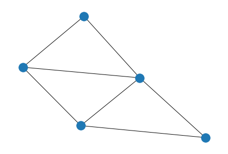

```python
import numpy as np

# -----------------------------------------------------------------
# Case 1: connected graph
# Set adjacency matrix
A = np.array([
    [0, 1, 1, 0, 0],
    [1, 0, 1, 1, 0],
    [1, 1, 0, 1, 1],
    [0, 1, 1, 0, 1],
    [0, 0, 1, 1, 0]])

# Laplace matrix
D_d = np.diag([sum(A[i, :]) for i in range(len(A))])
L = D_d - A

spec_L = np.linalg.eigvals(L)
print ('Case1: ', spec_L)

# Conclusion: number of 0 in spectrum is 1, therefore there is one component of the graph

# Create graph
G = nx.from_numpy_matrix(A)
# Draw it
plt.figure(1)
nx.draw(G)
plt.show()
```

```
Case 2:  [ 3. -0.  3.  2.  0.]
```

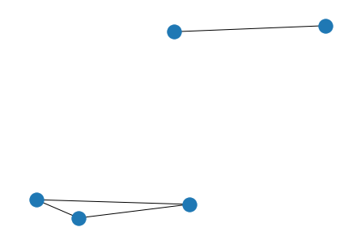

```python
import networkx as nx
import matplotlib.pyplot as plt
import graphviz as grv

# -----------------------------------------------------------------
# Case 2: Two component graph
# Set adjacency matrix
A = np.array([
    [0, 1, 1, 0, 0],
    [1, 0, 1, 0, 0],
    [1, 1, 0, 0, 0],
    [0, 0, 0, 0, 1],
    [0, 0, 0, 1, 0]])

# Laplace matrix
D_d = np.diag([sum(A[i, :]) for i in range(len(A))])
L = D_d - A

spec_L = np.linalg.eigvals(L)
print ('Case 2: ', np.round(spec_L, 6))

# Conclusion: number of 0 in spectrum is 2, therefore there are two components of the graph

# Create graph
G = nx.from_numpy_matrix(A)
# Draw it
plt.figure(1)
nx.draw(G)
plt.show()
```

4. Teorija grafov

4.1 Definicija, predstavitev in osnovne lastnosti

## ■ Stopnja vozlišča in regularnost

- Stopnja vozlišča:
  - Oznaka $deg(u)=|N(u)|$
  - $\delta(G) = min(deg(u))$, $u\in V$
  - $\Delta(G) = max(deg(u))$, $u\in V$
- Regularen graf: vse stopnje vozlišč so enake:
  - $deg(u)=\delta(G)=\Delta(𝐺)$ za vsak $u\in V$
  - r-regularen graf: $r=deg(G)$, $u\in V$
- Lema o rokovanju: $$ \sum_{v\in V(G)} deg(v) = 2|E(G)| $$

14

[figure not shown]

4. Teorija grafov

4.1 Definicija, predstavitev in osnovne lastnosti

## ■ Omejitve glede |V| in |E|

- Omejitve velikosti množic $V$ in $E$ grafa $G=(V, E)$: graf na $n$ točkah ($n=|𝑉|$, $m=|E|$) ima največ povezav:
  - $m\leq n(n-1)$, če je usmerjen in ne dovolimo zank
  - $m\leq n^2$, če je usmerjen in dovolimo zanke
  - $m\leq n(n-1)/2$, če je neusmerjen in ne dovolimo zank
  - $m\leq n(n+1)/2$, če je neusmerjen in dovolimo zanke

15

[figure not shown]

4. Teorija grafov

4.1 Definicija, predstavitev in osnovne lastnosti

## ■ Vložitev in označevanje grafa (ang. labelinng)

- Vložite grafa v množico $Y$, navadno je to $ℝ^2$ ali izbrana plosekv
  - Kje so vozlišča: $\varphi: V \to Y$
  - Kje so povezave: $\psi: E \to Y$
- Označevanje vozlišč
  - Oznake so dodane oznake: $L_V: V\to A$
  - Npr. metapodatki uporabnikov v grafu uporabnikov
- Označevanje povezav
  - Labele so dodane oznake: $L_E: E\to B$
  - Navadno so to uteži na povezavah

16

[figure not shown]

4. Teorija grafov

4.1 Definicija, predstavitev in osnovne lastnosti

## ■ Podgraf, sprehod, pot, cikel

- Podgraf: $H\subset G$ če je $V(H)\subset V(G)$ in $E(H)\subset E(G)$
- Sprehod: zaporedje vozlišč $P=(v_1, \ldots v_k)$ tako da je $(v_i, v_{i+1})\in E$
- Pot: sprehod z različnimi vozlišči: $S=(v_1, \ldots v_k)$ in $v_i\ne v_j$ za $i\ne j$
- Cikel: zaključena pot $C=(v_1, \ldots v_{k-1}, v_1)$.
- Eulerjev sprehod, Eulerjev cikel, Eulerjev graf: sprehod/cikel, ki vsebuje vse povezave. Graf je Eulerjev, če vsebuje Eulerjev cikel:
  - Digraf je Eulerjev natanko tedaj, ko sta vhodna in izhodna stopnja vsake točke enaki in je graf povezan.
  - Odločitev ali je graf Eulerjev: 𝑂(|𝑉|)

17

[figure not shown]

4. Teorija grafov

4.2. Izbrani problemi in algoritmi na grafih

## 4.2. Izbrani problemi in algoritmi na grafih

■ Pregled grafa $\large{*}$

■ Podgraf, sprehod, pot, cikel $\large{*}$

■ Hamiltonova pot in cikel $\large{*}$

■ Klika in neodvisna podmnožica

■ Najmanjše vpeto drevo $\large{*}$

■ Povezanost grafa $\large{*}$

■ Ravninski grafi $\large{*}$

■ Barvanje grafa

■ Problem najkrajše (najcenejše) poti $\large{*}$

■ Problem maksimalnega pretoka $\large{*}$

■ Problem trgovskega potnika

■ Risanje grafov

19

[figure not shown]

4. Teorija grafov

4.2. Izbrani problemi in algoritmi na grafih

## ■ Pregled grafa

- Sprehod v širino (ang. Breath first search, BFS)
  - Najprej vse sosede – algoritem z vrsto
  - Obišče začetno komponento
  - Zahtevnost $O(|V|)$
- Sprehod v globino (ang. Deph first search, DFS)
  - Najprej sosede sosedov – rekurzija
  - Obišče začetno komponento
  - Zahtevnost $O(|V|)$
- Slučajni sprehod: naključna izbira sosednjih vozlišč
  - Naključno izbira vozlišč
  - Porazdelitve glede na uteži povezav

20

[figure not shown]

4. Teorija grafov

4.2. Izbrani problemi in algoritmi na grafih

## ■ Najmanjše vpeto drevo

- Kaj je najmanjše vpeto drevo: $T\subset G$ tako, da je
  - $V(T)=V(G)$
  - $T$ je drevo (graf brez ciklov)
- Kruskalov algoritem:
  - **Require**: Povezan graf 𝐺=(𝑉, 𝐸);
  - **Ensure:** Najmanjše vpeto drevo
  - Časovna zahtevnost: $O(|E|\log|E|) = O(|E|\log|V|)$

21

[figure not shown]

4. Teorija grafov

4.2. Izbrani problemi in algoritmi na grafih

## ■ Povezanost grafa

- V neusmerjene grafu:
  - $u$ in $v$ sta povezani, če med njima obstaja pot
  - Povezana komponenta: maksimalna množica povezanih vozlišč
- V usmerjenem grafu
  - $u$ in $v$ sta šibko povezani, če med njima obstaja pot vsaj v eno smer
  - $u$ in $v$ sta krepko povezani, če med njima obstaja pot v obe smeri
  - (krepko, šibko) povezana komponenta: maksimalna množica povezanih vozlišč
- Algoritem za iskanje komponent
  - Sprehod v širino ali globino iz dane točke da eno komponento;
  - Nadaljujemo v poljubni preostali točki;
  - Zahtevnost: $O(|V|+|E|)$
- $K$-povezanost
  - Množica k-rez: $V_k\subset V$, pri kateri $G\setminus V_k$ ni več povezan
  - $G$ je $k$-povezan, če obstaja najmanjša rez množica velikosti $|V_k|=k$.
  - Povezano z maksimalnim pretokom (Mengerjev teorem)

22

[figure not shown]

4. Teorija grafov

4.2. Izbrani problemi in algoritmi na grafih

## ■ Ravninski grafi

- **Definicija:** Graf je ravninski, če ga je mogoče narisati v ravnino brez križanja povezav.
- Eulerjeva karakteristika: za povezan ravninski graf oznake $n=|V|$, $m=|E|$, $f=|F|$, $F$ je množica lic, velja $$ n - m + f = 2 $$
- Izrek Kuratowskega: Graf je ravninski natanko tedaj, ko ne vsebuje podgrafa, ki je subdivizija $K_{3,3}$ ali $K_5$.
- Opomba: Slovenski prispevek k prepovedanim grafom na torusu (Mohar, Juvan).

23

[figure not shown]

4. Teorija grafov

4.2. Izbrani problemi in algoritmi na grafih

## ■ Barvanje grafa

- Barvanje grafa je preslikava $$ c:V→\{1,…, b\}. $$
- Barvanje je dobro, če za vsako povezavo $(u,v)\in E$ vozliščema priredi različno barvi, torej $c(u)\ne c(v)$.
- Kromatično število 𝜒(𝐺): najmanjše število barv, potrebno za dobro barvanje grafa
  - Velja $\chi(G) \leq \Delta(G)+1$
  - $\chi(T)=2$ za $T$ je drevo
  - $\chi(G)=4$ za $G$ ravninski

24

[figure not shown]

4. Teorija grafov

4.2. Izbrani problemi in algoritmi na grafih

## ■ Problem najkrajše (najcenejše) poti

- Problem najkrajših poti:
  - Varianta A: Za dano vozlišče $s$ nas zanimajo najkrajše poti od $s$ do vseh ostalih vozlišč (ang. single-source shortest paths)
  - Varianta B: Ali pa: za vsako vozlišče $s$ nas zanimajo najkrajše poti od $s$ do vseh ostalih vozlišč (angl. all-pairs shortest paths)
- Dijkstra algoritem
  - **Require**: Povezan graf $G=(V, E)$, vozlišče $s$;
  - **Ensure**: Najkrajše poti od $s$ ostalih vozlišč
  - Časovna zahtevnost: $O((|V|+|E|) log(|V|))$ s kopico

25

[figure not shown]

4. Teorija grafov

4.2. Izbrani problemi in algoritmi na grafih

## ■ Problem maksimalnega pretoka

- Problem maksimalnega pretoka
  - Graf $G=(V, E)$: omrežje;
  - Kapacitete povezav: $c: E\to ℝ_+$;
  - Pretok: $f: E\to ℝ_+$;
  - Poišči pot med vozliščema $s$ in $t$ iz $V$, ki da največji pretok $f_m$;
- Ford–Fulkerson algoritem
  - **Require**: Povezan graf $G=(V, E)$, vozlišči $s$ in $t$;
  - **Ensure**: Pot $P=(s, v_2, \ldots, t)$ in maksimalen pretok $f_m$
  - Časovna zahtevnost: $O(|E| f_m)$ za $f: 𝐸 \to ℕ_+$ (celoštevilski pretoki), $f_m$ je maksimalni pretok, brez garancije za konvergenco
- Zanesljiv algoritem:
  - Edmonds–Karp algorithm,
  - Zahtevnost $O(|V| |E|^2)$, neodvisen od maksimalnega pretoka

26

[figure not shown]

4. Teorija grafov

4.2. Izbrani problemi in algoritmi na grafih

## ■ Problem trgovskega potnika

- Problem trgovskega potnika
  - Graf $G=(V, E)$: mesta, povezana s cestami;
  - Razdalje povezav: $d: E \to ℝ_+$;
  - Poišči najkrajšo pot iz $s$ nazaj v $s$, ki obišče vse točke iz $V$.
- Rešitev: dinamično programiranje, celoštevilsko programiranje
  - **Require**: Povezan graf $G=(V, E)$, $d:E \to ℝ_+$;
  - **Ensure**: Najkrajša pot $P=(v_1,\ldots, v_n)$, ki obišče vsa vozlišča
  - Zahtevnost: $O(2^n)$.

27

[figure not shown]

4. Teorija grafov

4.2. Izbrani problemi in algoritmi na grafih

## ■ Risanje grafov

- Pomembno za vizualizacijo kompleksnih podatkov
- Orodje Graphviz: http://www.graphviz.org/
- Orodje Gephi: http://gephi.org
- Orodje SageMath: http://www.sagemath.org/
- Orodje Seeing theory: http://students.brown.edu/seeing-theory/
- Orodje Vis: http://visjs.org/
- Orodje Graphs for Neo4j: https://neo4j.com/developer/guide-data-visualization/
- Orodje Canviz: https://code.google.com/archive/p/canviz/

28

[figure not shown]

4. Teorija grafov

4.2. Izbrani problemi in algoritmi na grafih

## ■ Zaključki

- Graf je podatkovna struktura za
  - Model TK omrežja
  - Model socialnega omrežja uporabnikov
  - Formulacijo in realizacijo algoritmov
- Pomembni optimizacijski problemi so formulirani v jeziku teorije grafov
- Grafovski algoritmi so tesno povezani s TK

29

[figure not shown]